## Assignment 5

Derek Rouch

LLO 8200

Introduction to Data Science

September 22, 2019

#### Setting up R

To begin, I cleared my Global Environment and retrieved the necessary libraries. I also set my working directory to my GitHub repository folder.

#### 1. Create a twittR Account. What is your consumerKey? What is your accessToken?

My consumerKey and accessToken can be found below.

```r
## Establish API keys and access tokens
consumerKey='68bxc6lCLWKkMPVVKYgCzl9DO'
consumerSecret='QJumJXPJqNxTIbQm0CARNtOnOVTXGO1USqiE3OF3taMY0h99kA'
access_Token='1056575519443931136-ihgtVbXKExFBLcSo4A8gzYIEFQ9gdX'
access_Secret='xcD5nPWkFgz0586tsj4hiejHE9OoeQ1awwJLfRGCiNs4f'

requestURL='https://api.twitter.com/oauth/request_token'
accessURL='https://api.twitter.com/oauth/access_token'
authURL='https://api.twitter.com/oauth/authorize'

#filename="TwitterConKey_ConSec_AccTok_AccSec.txt"
#(tokens<-read.csv(filename, header=TRUE, sep=","))
#(consumerKey=as.character(tokens$consumerKey))
#consumerSecret=as.character(tokens$consumerSecret)
#access_Token=as.character(tokens$access_Token)
#access_Secret=as.character(tokens$access_Secret)
```

#### 2. Run example 07-twitterAPI.rmd. Use hashtag: Trump. What are the 5 most common words contained within collected tweets.

First, I set up the OAuth credentials and searched #Trump. Then I converted the results to a data frame.

```r
## Set up the OAuth credentials for a twitteR session
setup_twitter_oauth(consumerKey,consumerSecret,access_Token,access_Secret)
```

```
## [1] "Using direct authentication"
```

```r
## Scours twitter for hash tag
jackass <- twitteR::searchTwitter("#Trump",n=50,since="2019-09-09")

## Convert twitteR list to data.frames
jackass_df <- twListToDF(jackass)
```

I then stored the tweets as a .csv file.

```r
## Store the tweets in a .csv file
tweets_file = "tweets.csv"
(jackass_df$text[1])
```

```
## [1] "RT @BrandonStraka: “I’m here to represent a different point of view on the Hollywood Red Carpet... you don’t have to be a liberal and you d…"
```

```r
## Start the file
tweets_csv <- file(tweets_file)

## Tokenize tweets into a list of words
tokens <- tokenizers::tokenize_words(jackass_df$text[1],stopwords = stopwords::stopwords("en"),
          lowercase = TRUE,  strip_punct = TRUE, strip_numeric = TRUE,simplify = TRUE)

## Write squished tokens
cat(unlist(str_squish(tokens)), "\n", file=tweets_csv, sep=",")
close(tweets_csv)

## Append remaining lists of tokens into file
tweets_csv <- file(tweets_file, open = "a")
token_list = tokens
for(i in 2:nrow(jackass_df)){
  tokens<-tokenize_words(jackass_df$text[i],stopwords = stopwords::stopwords("en"),
            lowercase = TRUE,  strip_punct = TRUE, simplify = TRUE)
  cat(unlist(str_squish(tokens)), "\n", file=tweets_csv, sep=",")
  token_list <- c(token_list,  unlist(str_squish(tokens)))
}
close(tweets_csv)
```

I then transformd the list of words into a `TermDocumentMatrix`.

```r
## Create frequency table
cor <- Corpus(VectorSource(token_list))

tdm <- TermDocumentMatrix(cor)
m <- as.matrix(tdm)
v <- sort(rowSums(m),decreasing=TRUE)
d <- data.frame(word = names(v),freq=v)
```

By viewing `d` and ignoring some of the terms that don’t make sense for this analysis—such as *trump*, *https*, *t.co*, and *don’t*—the five most common words were: *Modi*, *Indian*, *Houston*, *Tarek Fatah*, and *Pakistan’s*.

#### Run this RMD file and choose your favorite hashtag, e.g. chocolate. Create a wordcloud using words from all collected tweets.

I followed the same sequence of steps as in #2, only this time I scraped Twitter for #RagnarRelay, which is a 200-ish mile road race I ran last week with my wife and some of our friends in Colorado.

Finally, I removed the *https* and *t.co* observations and used the `wordcloud` function to visualize the popularity of words.

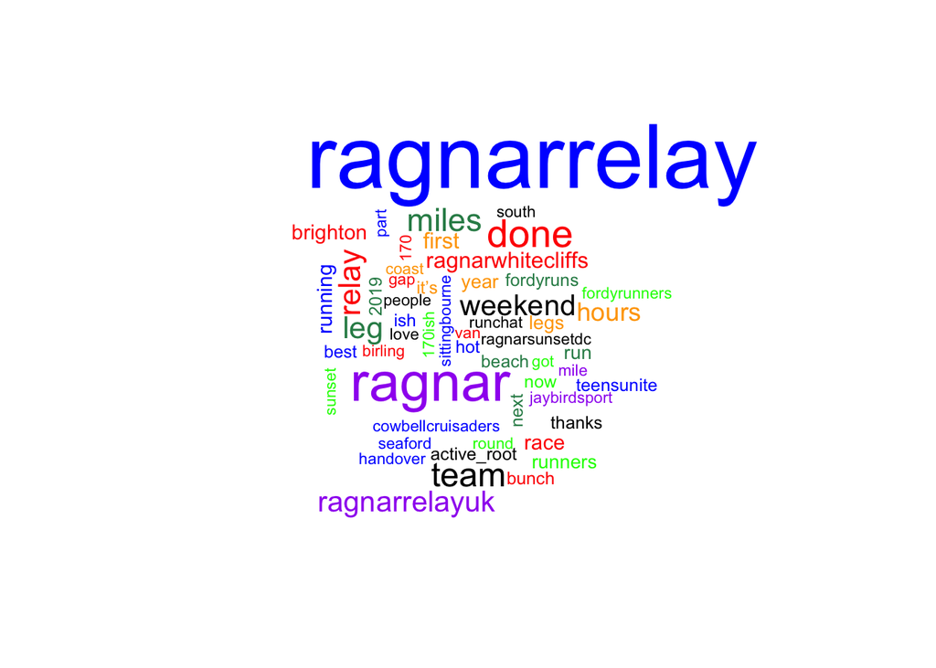

```r
## Create a subset with unimportant values removed
d2_cleaned <- d2[3:417,]

## Create a wordcloud
wordcloud(d2_cleaned$word,d2_cleaned$freq, colors=c("red","green","blue","orange","black","purple", "seagreen") , random.color = TRUE, min.freq = 3)
```